# Taxonomy Reconciliation QA Review

GBIF Gap Analysis — Verifying 09a Matching Results

gbifgaps

February 15, 2026

# Overview

This report reviews the taxonomy reconciliation produced by `09a_reconcile_taxonomy.R`. It helps you verify match quality and identify species that could be resolved with manual overrides.

```r
recon <- as.data.table(readRDS(here(p_data_proc, "taxonomic_reconciliation.rds")))
taxa  <- as.data.table(readRDS(here(p_data_proc, "taxa_reference_current.rds")))

taxa[, name_std := tolower(trimws(scientificName))]
taxa[, is_accepted := (taxonID == acceptedNameUsageID)]

n_total     <- nrow(recon)
n_matched   <- sum(recon$match_tier != "unmatched")
n_unmatched <- sum(recon$match_tier == "unmatched")
occ_total   <- sum(as.numeric(recon$total_occ))
occ_matched <- recon[match_tier != "unmatched", sum(as.numeric(total_occ))]
```

**Reconciliation summary:** 56,345 of 67,668 GBIF species matched to the national backbone (83.3% of species, 99.8% of occurrences).

```r
tier_summary <- recon[, .(
  Species = .N,
  Occurrences = sum(as.numeric(total_occ)),
  `% Species` = round(100 * .N / n_total, 1),
  `% Occurrences` = round(100 * sum(as.numeric(total_occ)) / occ_total, 2)
), by = .(Tier = match_tier, Type = match_type)][order(Tier, -Species)]

kable(tier_summary, format.args = list(big.mark = ","))
```

| Tier | Type | Species | Occurrences | % Species | % Occurrences |
| --- | --- | --- | --- | --- | --- |
| tier1 | accepted_name | 49,931 | 267,850,375 | 73.8 | 96.33 |
| tier2 | synonym | 3,473 | 5,041,544 | 5.1 | 1.81 |
| tier2_ambiguous | synonym | 236 | 2,595,089 | 0.3 | 0.93 |
| tier3 | infraspecific_collapse | 38 | 1,582 | 0.1 | 0.00 |
| tier4 | gbif_api_synonym | 2,667 | 1,904,310 | 3.9 | 0.68 |
| unmatched | binomial_no_match | 10,622 | 617,066 | 15.7 | 0.22 |
| unmatched | genus_only | 693 | 57,902 | 1.0 | 0.02 |
| unmatched | hybrid | 6 | 548 | 0.0 | 0.00 |
| unmatched | other | 2 | 184 | 0.0 | 0.00 |

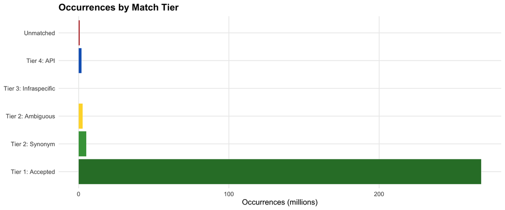

```r
tier_occ <- recon[, .(
  occ = sum(as.numeric(total_occ))
), by = match_tier]

tier_order <- c("tier1", "tier2", "tier2_ambiguous", "tier3", "tier4", "unmatched")
tier_labels <- c("Tier 1: Accepted", "Tier 2: Synonym", "Tier 2: Ambiguous",
                  "Tier 3: Infraspecific", "Tier 4: API", "Unmatched")
tier_colors <- c("#2E7D32", "#43A047", "#FDD835", "#66BB6A", "#1565C0", "#B71C1C")

tier_occ[, tier_f := factor(match_tier, levels = tier_order, labels = tier_labels)]
tier_occ <- tier_occ[!is.na(tier_f)]

ggplot(tier_occ, aes(x = tier_f, y = occ / 1e6, fill = tier_f)) +
  geom_col() +
  scale_fill_manual(values = setNames(tier_colors, tier_labels), guide = "none") +
  scale_y_continuous(labels = comma) +
  labs(title = "Occurrences by Match Tier",
       x = NULL, y = "Occurrences (millions)") +
  coord_flip()
```

# 1. Ambiguous Synonym Matches

These species matched a backbone synonym name that points to **more than one accepted taxon**. The script took the first match. Review these to confirm correctness — especially the high-occurrence ones.

## All Ambiguous Matches

```r
ambig <- recon[match_tier == "tier2_ambiguous",
               .(species, backbone_scientificName, total_occ,
                 match_name_used)][order(-total_occ)]

if (nrow(ambig) > 0) {
  # For each ambiguous match, find ALL possible accepted taxa
  ambig_detail <- rbindlist(lapply(seq_len(nrow(ambig)), function(i) {
    nm <- tolower(trimws(ambig$species[i]))
    # Find all synonym rows for this name
    syn_rows <- taxa[!is_accepted & name_std == nm]
    if (nrow(syn_rows) == 0) return(NULL)

    # Get their accepted taxa
    accepted_ids <- unique(syn_rows$acceptedNameUsageID)
    accepted_names <- taxa[taxonID %in% accepted_ids & is_accepted,
                           .(acceptedNameUsageID = taxonID, accepted_name = scientificName)]

    data.table(
      gbif_species = ambig$species[i],
      total_occ = ambig$total_occ[i],
      chosen_match = ambig$backbone_scientificName[i],
      all_candidates = paste(accepted_names$accepted_name, collapse = " | "),
      n_candidates = nrow(accepted_names)
    )
  }))

  datatable(
    ambig_detail,
    caption = glue("{nrow(ambig)} ambiguous synonym matches"),
    filter = "top",
    options = list(pageLength = 25, order = list(list(1, "desc"))),
    rownames = FALSE
  ) |> formatCurrency("total_occ", currency = "", digits = 0)
} else {
  cat("No ambiguous matches found.")
}
```

| gbif_species | total_occ | chosen_match | all_candidates | n_candidates |
| --- | --- | --- | --- | --- |
| Corvus cornix | 2245884 | Corvus corone cornix | Corvus corone cornix | 1 |
| Ochlodes venata | 83564 | Ochlodes sylvanus | Ochlodes sylvanus | 1 |
| Rhodofomes roseus | 71536 | Fomitopsis rosea | Fomitopsis rosea | 1 |
| Galium album | 34112 | Galium mollugo subsp. erectum | Galium mollugo subsp. erectum | 1 |
| Inonotus leporinus | 23914 | Pelloporus leporinus | Pelloporus leporinus | 1 |
| Plicaturopsis crispa | 17588 | Plicatura crispa | Plicatura crispa | 1 |
| Xylodon radula | 9612 | Basidioradulum radula | Basidioradulum radula | 1 |
| Plagiochila asplenioides | 8956 | Plagiochila asplenioides s.lat. | Plagiochila asplenioides s.str. \| Plagiochila asplenioides s.lat. | 2 |
| Stellaria apetala | 8274 | Stellaria media | Stellaria media \| Stellaria pallida | 2 |
| Radula complanata | 7198 | Radula complanata s.lat. | Radula complanata s.str. \| Radula complanata s.lat. | 2 |

[output cut: 226 more lines]

## Flagged for Review

These ambiguous matches have **> 5,000 occurrences** and deserve manual verification:

```r
if (exists("ambig_detail") && nrow(ambig_detail) > 0) {
  flagged <- ambig_detail[total_occ > 5000][order(-total_occ)]
  if (nrow(flagged) > 0) {
    kable(flagged, format.args = list(big.mark = ","))
  } else {
    cat("No high-occurrence ambiguous matches.")
  }
} else {
  cat("No ambiguous matches to review.")
}
```

| gbif_species | total_occ | chosen_match | all_candidates | n_candidates |
| --- | --- | --- | --- | --- |
| Corvus cornix | 2,245,884 | Corvus corone cornix | Corvus corone cornix | 1 |
| Ochlodes venata | 83,564 | Ochlodes sylvanus | Ochlodes sylvanus | 1 |
| Rhodofomes roseus | 71,536 | Fomitopsis rosea | Fomitopsis rosea | 1 |
| Galium album | 34,112 | Galium mollugo subsp. erectum | Galium mollugo subsp. erectum | 1 |
| Inonotus leporinus | 23,914 | Pelloporus leporinus | Pelloporus leporinus | 1 |
| Plicaturopsis crispa | 17,588 | Plicatura crispa | Plicatura crispa | 1 |
| Xylodon radula | 9,612 | Basidioradulum radula | Basidioradulum radula | 1 |
| Plagiochila asplenioides | 8,956 | Plagiochila asplenioides s.lat. | Plagiochila asplenioides s.str. \| Plagiochila asplenioides s.lat. | 2 |
| Stellaria apetala | 8,274 | Stellaria media | Stellaria media \| Stellaria pallida | 2 |
| Radula complanata | 7,198 | Radula complanata s.lat. | Radula complanata s.str. \| Radula complanata s.lat. | 2 |
| Lenzites betulinus | 6,810 | Trametes betulina | Trametes betulina | 1 |
| Senecio vernalis | 6,644 | Senecio leucanthemifolius subsp. vernalis | Senecio leucanthemifolius subsp. vernalis | 1 |
| Salix fragilis | 6,424 | Salix × fragilis | Salix × fragilis \| Salix euxina | 2 |
| Bubulcus ibis | 5,296 | Ardea ibis/coromanda | Ardea ibis/coromanda \| Ardea ibis | 2 |

# 2. Tier 4 Matches (GBIF API)

These were resolved by querying the GBIF Species API for synonyms. The matches are generally reliable (the API provides the authoritative synonym chain), but it’s good to scan the high-occurrence ones.

## Top 50 by Occurrences

```r
t4 <- recon[match_tier == "tier4",
            .(species, backbone_scientificName, match_name_used,
              total_occ)][order(-total_occ)]

datatable(
  head(t4, 50),
  caption = glue("{comma(nrow(t4))} total Tier 4 matches — showing top 50"),
  filter = "top",
  options = list(pageLength = 25),
  rownames = FALSE
) |> formatCurrency("total_occ", currency = "", digits = 0)
```

| species | backbone_scientificName | match_name_used | total_occ |
| --- | --- | --- | --- |
| Phylloscopus sibillatrix | Phylloscopus sibilatrix | motacilla sibilatrix | 374566 |
| Acanthis hornemanni | Acanthis flammea | acanthis flammea | 70580 |
| Thysselinum palustre | Peucedanum palustre | peucedanum palustre | 42506 |
| Plebejus amanda | Polyommatus amandus | polyommatus amandus | 39016 |
| Lolium pratense | Schedonorus pratensis | schedonorus pratensis | 28904 |
| Parmeliella thriptophylla | Parmeliella triptophylla | parmeliella triptophylla | 28620 |
| Lycaeides idas | Plebejus argyrognomon | plebejus argyrognomon | 26904 |
| Nyea lurideola | Eilema lurideola | eilema lurideola | 23356 |
| Rabelera holostea | Stellaria holostea | stellaria holostea | 21993 |
| Xanthoporia radiata | Mensularia radiata | mensularia radiata | 21574 |

[output cut: 40 more lines]

## Match Patterns

```r
if (nrow(t4) > 0) {
  # Classify: same epithet (genus move) vs different epithet (true synonym)
  t4[, gbif_epithet := word(tolower(species), 2)]
  t4[, backbone_epithet := word(tolower(backbone_scientificName), 2)]
  t4[, pattern := fifelse(gbif_epithet == backbone_epithet,
                          "Genus reclassification", "Different epithet (true synonym)")]

  pattern_summary <- t4[, .(n = .N, occ = sum(as.numeric(total_occ))), by = pattern]
  kable(pattern_summary, format.args = list(big.mark = ","),
        col.names = c("Pattern", "Species", "Occurrences"))
}
```

| Pattern | Species | Occurrences |
| --- | --- | --- |
| Different epithet (true synonym) | 1,679 | 1,188,414 |
| Genus reclassification | 985 | 696,500 |
| NA | 3 | 19,396 |

# 3. Unmatched Species Analysis

## Overview

```r
unmatched <- recon[match_tier == "unmatched"]

unmatched_summary <- unmatched[, .(
  n = .N,
  total_occ = sum(as.numeric(total_occ)),
  max_occ = max(total_occ)
), by = match_type][order(-total_occ)]

kable(unmatched_summary, format.args = list(big.mark = ","),
      col.names = c("Category", "Species", "Total Occurrences", "Max Occurrences"))
```

| Category | Species | Total Occurrences | Max Occurrences |
| --- | --- | --- | --- |
| binomial_no_match | 10,622 | 617,066 | 108,618 |
| genus_only | 693 | 57,902 | 2,226 |
| hybrid | 6 | 548 | 460 |
| other | 2 | 184 | 178 |

## Top Unmatched Binomials — Epithet Candidates

For the highest-occurrence unmatched binomials, we check if the **species epithet** exists in the backbone under a different genus. These are the best candidates for manual resolution — likely genus reclassifications that the GBIF API missed or that fell below the API threshold.

```r
# Get unmatched binomials with significant occurrences
unmatched_binom <- unmatched[match_type %in% c("binomial_no_match", "below_api_threshold") &
                               grepl(" ", species)]
unmatched_binom[, `:=`(
  genus   = word(tolower(species), 1),
  epithet = word(tolower(species), 2)
)]

# Build backbone epithet lookup (accepted + synonym names, binomials only)
backbone_binomials <- taxa[nchar(name_std) > 0 &
                            sapply(strsplit(name_std, "\\s+"), length) == 2]
backbone_binomials[, `:=`(
  d_genus   = word(name_std, 1),
  d_epithet = word(name_std, 2)
)]

# For each unmatched species, find backbone names sharing the epithet
epithet_candidates <- rbindlist(lapply(
  seq_len(nrow(unmatched_binom)),
  function(i) {
    ep <- unmatched_binom$epithet[i]
    gn <- unmatched_binom$genus[i]

    # Find backbone names with same epithet but different genus
    matches <- backbone_binomials[d_epithet == ep & d_genus != gn]
    if (nrow(matches) == 0) return(NULL)

    # Get accepted name for each match
    match_info <- merge(
      matches[, .(name_std, taxonID, acceptedNameUsageID, is_accepted)],
      taxa[is_accepted == TRUE, .(taxonID, accepted_scientificName = scientificName)],
      by.x = "acceptedNameUsageID", by.y = "taxonID",
      all.x = TRUE
    )

    # Deduplicate: unique accepted taxa
    accepted_options <- unique(match_info[!is.na(accepted_scientificName),
                                          .(accepted_scientificName)])

    data.table(
      gbif_species     = unmatched_binom$species[i],
      total_occ        = unmatched_binom$total_occ[i],
      epithet          = ep,
      backbone_candidates = paste(unique(accepted_options$accepted_scientificName),
                                  collapse = " | "),
      n_candidates     = nrow(accepted_options),
      match_category   = unmatched_binom$match_type[i]
    )
  }
))
```

```r
if (!is.null(epithet_candidates) && nrow(epithet_candidates) > 0) {
  # Split into high-confidence (1 candidate) and ambiguous (>1)
  single <- epithet_candidates[n_candidates == 1][order(-total_occ)]
  multi  <- epithet_candidates[n_candidates > 1][order(-total_occ)]
  none   <- unmatched_binom[!species %in% epithet_candidates$gbif_species][order(-total_occ)]

  cat(glue("**{comma(nrow(epithet_candidates))}** unmatched species share an epithet with the backbone:
- **{nrow(single)}** have exactly 1 backbone candidate (high confidence)
- **{nrow(multi)}** have multiple candidates (need manual review)
- **{comma(nrow(none))}** have no epithet match in the backbone at all\n\n"))
} else {
  cat("No epithet candidates found.\n")
}
```

```
## **4,948** unmatched species share an epithet with the backbone:
## - **818** have exactly 1 backbone candidate (high confidence)
## - **4130** have multiple candidates (need manual review)
## - **5,674** have no epithet match in the backbone at all
```

### High-Confidence Candidates (1 backbone match)

```r
if (exists("single") && nrow(single) > 0) {
  datatable(
    single[, .(gbif_species, backbone_candidates, total_occ, match_category)],
    caption = glue("{nrow(single)} high-confidence epithet matches"),
    filter = "top",
    options = list(pageLength = 50, order = list(list(2, "desc"))),
    rownames = FALSE,
    colnames = c("GBIF Species", "Backbone Match", "Occurrences", "Why Unmatched")
  ) |> formatCurrency("total_occ", currency = "", digits = 0)
} else {
  cat("None found.")
}
```

| GBIF Species | Backbone Match | Occurrences | Why Unmatched |
| --- | --- | --- | --- |
| Agriphila tristellus | Metriocnemus tristellus | 20212 | binomial_no_match |
| Viola wittrockiana | Gloeochaete wittrockiana | 6380 | binomial_no_match |
| Rhagio scolopacea | Limnodromus scolopaceus | 5684 | binomial_no_match |
| Cortinarius mammillatus | Parasitus mammillatus | 3303 | binomial_no_match |
| Lepisma saccharinum | Acer saccharinum | 2000 | binomial_no_match |
| Lobesia fuligana | Pristerognatha fuligana | 1124 | binomial_no_match |
| Anacaena globula | Euzetes globulus | 849 | binomial_no_match |
| Anasimyia interpunctus | Microterys interpunctus | 792 | binomial_no_match |
| Crocinitomix algicola | Collotheca ambigua | 664 | binomial_no_match |
| Megaselia tenebricola | Tenuiphantes tenebricola | 612 | binomial_no_match |

[output cut: 808 more lines]

### Ambiguous Candidates (> 1 backbone match)

These need manual review — the epithet appears under multiple genera in the backbone, so automated resolution is risky.

```r
if (exists("multi") && nrow(multi) > 0) {
  datatable(
    multi[, .(gbif_species, backbone_candidates, n_candidates, total_occ)],
    caption = glue("{nrow(multi)} ambiguous epithet matches"),
    filter = "top",
    options = list(pageLength = 50, order = list(list(3, "desc"))),
    rownames = FALSE,
    colnames = c("GBIF Species", "Backbone Candidates", "N", "Occurrences")
  ) |> formatCurrency("total_occ", currency = "", digits = 0)
} else {
  cat("None found.")
}
```

| GBIF Species | Backbone Candidates | N | Occurrences |
| --- | --- | --- | --- |
| Spinulum annotinum | Lycopodium annotinum \| Pohlia annotina | 2 | 108618 |
| Trommsdorffia maculata | Xylomya maculata \| Anaspis maculata \| Rutpela maculata \| Siphona maculata \| Portevinia maculata \| Canthidermis maculata \| Miscogaster maculata \| Aleochara maculata \| Euophrys frontalis \| Dact… | 64 | 36020 |
| Hieracium lachenalii | Oenanthe lachenalii \| Carex lachenalii | 2 | 14948 |
| Chaetoceros sociale | Schadonia fecunda \| Dinobryon sociale \| Tetrabaena socialis \| Oedogonium sociale | 4 | 5114 |
| Podila humilis | Andrena humilis \| Tipula humilis \| Bombus humilis \| Stenus humilis \| Cyclodinus humilis \| Linepithema humile \| Aphelinus humilis \| Aprostocetus humilis \| Elachista humilis \| Araeoncus humilis… | 41 | 3836 |
| Chrysotoxum bicincta | Aphrodes bicinctus \| Paraplatypeza bicincta \| Exechia bicincta \| Anaretella defecta \| Lissonota bicincta \| Lecanora bicincta | 6 | 3506 |
| Solicoccozyma terricola | Laemostenus terricola \| Margarinotus terricola \| Tropiphorus terricola \| Trochosa terricola \| Archaeodictyna consecuta \| Petaloproctus terricolus \| Protoblastenia terricola \| Chlorella vulgaris… | 18 | 3028 |
| Cinara pruinosum | Scoliciosporum pruinosum \| Schistidium pruinosum \| Xylodon detriticus \| Rhizocybe pruinosa \| Xenasma pruinosum | 5 | 2696 |
| Centrotus cornuta | Gymnosporangium cornutum \| Hydroptila cornuta \| Tetramesa cornuta \| Hypomma cornutum \| Viola cornuta \| Proceraea cornuta \| Syllis cornuta \| Intoshella cornuta \| Polydora cornuta \| Cladonia co… | 39 | 2644 |
| Priocnemis exaltatus | Echinops exaltatus \| Lycopus exaltatus | 2 | 2568 |

[output cut: 4120 more lines]

### No Epithet Match

These species have no shared epithet with any backbone name — they are likely genuinely absent from the national backbone (foreign vagrants, non-native species, or taxa the backbone doesn’t cover).

```r
if (exists("none") && nrow(none) > 0) {
  datatable(
    head(none[, .(species, total_occ, match_type)], 100),
    caption = glue("{comma(nrow(none))} species with no epithet in the backbone — top 100"),
    filter = "top",
    options = list(pageLength = 25, order = list(list(1, "desc"))),
    rownames = FALSE,
    colnames = c("GBIF Species", "Occurrences", "Category")
  ) |> formatCurrency("total_occ", currency = "", digits = 0)
} else {
  cat("None — all unmatched binomials share an epithet with the backbone.")
}
```

| GBIF Species | Occurrences | Category |
| --- | --- | --- |
| Hieracium levicaule | 12256 | binomial_no_match |
| Rhizosolenia fragillissima | 10610 | binomial_no_match |
| Stenomacrus affinitor | 3436 | binomial_no_match |
| Gymnometriocnemus kamimegavirgus | 3390 | binomial_no_match |
| Catoptria margaritellus | 2298 | binomial_no_match |
| Narcissus cyclazetta | 2288 | binomial_no_match |
| Polietes lardaria | 1934 | binomial_no_match |
| IMCC9063 sp000195085 | 1790 | binomial_no_match |
| Ctenolepisma longicaudatum | 1556 | binomial_no_match |
| Cortinarius rufo-olivaceus | 1536 | binomial_no_match |

[output cut: 90 more lines]

# 4. Manual Override Template

## Export for Review

This section exports a CSV you can edit to add manual overrides. Fill in the `accept` column with `TRUE` for matches you’ve verified, and `backbone_override` with the correct backbone name if the auto-suggested candidate is wrong.

```r
override_template <- NULL

if (exists("single") && nrow(single) > 0) {
  override_single <- single[, .(
    gbif_species,
    suggested_backbone = backbone_candidates,
    total_occ,
    source = "epithet_single_match",
    accept = NA,
    backbone_override = NA_character_,
    notes = NA_character_
  )]
  override_template <- override_single
}

if (exists("ambig_detail") && nrow(ambig_detail) > 0) {
  override_ambig <- ambig_detail[, .(
    gbif_species,
    suggested_backbone = chosen_match,
    total_occ,
    source = "tier2_ambiguous",
    accept = NA,
    backbone_override = NA_character_,
    notes = all_candidates
  )]
  override_template <- rbindlist(list(override_template, override_ambig), fill = TRUE)
}

if (!is.null(override_template) && nrow(override_template) > 0) {
  setorder(override_template, -total_occ)

  override_path <- here(p_data_proc, "taxonomy_manual_overrides_template.csv")
  fwrite(override_template, override_path)

  cat(glue("**Exported {nrow(override_template)} candidates** to:
`{override_path}`

Edit this file, set `accept = TRUE` for verified matches, then 09a can
read it as a Tier 0 override on the next run.\n\n"))

  datatable(
    head(override_template, 50),
    caption = "Top 50 override candidates (full list in CSV)",
    filter = "top",
    options = list(pageLength = 25, order = list(list(2, "desc"))),
    rownames = FALSE
  ) |> formatCurrency("total_occ", currency = "", digits = 0)
} else {
  cat("No override candidates to export.")
}
```

```
## **Exported 1054 candidates** to:
## `/Users/lenathol2503/Desktop/gbif_data_gaps/gbif_data_gaps_sweden/data_proc/taxonomy_manual_overrides_template.csv`
##
## Edit this file, set `accept = TRUE` for verified matches, then 09a can
## read it as a Tier 0 override on the next run.
```

| gbif_species | suggested_backbone | total_occ | source | accept | backbone_override | notes |
| --- | --- | --- | --- | --- | --- | --- |
| Corvus cornix | Corvus corone cornix | 2245884 | tier2_ambiguous |  |  | Corvus corone cornix |
| Ochlodes venata | Ochlodes sylvanus | 83564 | tier2_ambiguous |  |  | Ochlodes sylvanus |
| Rhodofomes roseus | Fomitopsis rosea | 71536 | tier2_ambiguous |  |  | Fomitopsis rosea |
| Galium album | Galium mollugo subsp. erectum | 34112 | tier2_ambiguous |  |  | Galium mollugo subsp. erectum |
| Inonotus leporinus | Pelloporus leporinus | 23914 | tier2_ambiguous |  |  | Pelloporus leporinus |
| Agriphila tristellus | Metriocnemus tristellus | 20212 | epithet_single_match |  |  |  |
| Plicaturopsis crispa | Plicatura crispa | 17588 | tier2_ambiguous |  |  | Plicatura crispa |
| Xylodon radula | Basidioradulum radula | 9612 | tier2_ambiguous |  |  | Basidioradulum radula |
| Plagiochila asplenioides | Plagiochila asplenioides s.lat. | 8956 | tier2_ambiguous |  |  | Plagiochila asplenioides s.str. \| Plagiochila asplenioides s.lat. |
| Stellaria apetala | Stellaria media | 8274 | tier2_ambiguous |  |  | Stellaria media \| Stellaria pallida |

[output cut: 40 more lines]

## How to Use Overrides

Once you’ve reviewed the CSV:

1. Open `data_proc/taxonomy_manual_overrides_template.csv`
2. For each row, set `accept = TRUE` if the suggested match is correct
3. If the suggestion is wrong but you know the correct name, fill in `backbone_override`
4. Save as `data_proc/taxonomy_manual_overrides.csv`
5. A future version of 09a can read this file as a “Tier 0” pre-match step

# 5. Summary Statistics

```r
cat(glue("
## Reconciliation Health Check

- **Total GBIF species:** {comma(n_total)}
- **Matched (Tiers 1-4):** {comma(n_matched)} ({round(100 * n_matched / n_total, 1)}%)
- **Occurrence coverage:** {round(100 * occ_matched / occ_total, 1)}%
- **Ambiguous matches needing review:** {nrow(ambig)} ({comma(sum(ambig$total_occ))} occ)
- **Unmatched with epithet candidate:** {if (exists('epithet_candidates') && nrow(epithet_candidates) > 0) comma(nrow(epithet_candidates)) else '0'}
- **Truly unresolvable:** {if (exists('none')) comma(nrow(none)) else 'unknown'}

### Potential improvement from manual overrides

"))
```

```
## ## Reconciliation Health Check
##
## - **Total GBIF species:** 67,668
## - **Matched (Tiers 1-4):** 56,345 (83.3%)
## - **Occurrence coverage:** 99.8%
## - **Ambiguous matches needing review:** 236 (2,595,089 occ)
## - **Unmatched with epithet candidate:** 4,948
## - **Truly unresolvable:** 5,674
##
## ### Potential improvement from manual overrides
```

```r
if (exists("single") && nrow(single) > 0) {
  potential_occ <- sum(as.numeric(single$total_occ))
  new_coverage <- round(100 * (occ_matched + potential_occ) / occ_total, 2)
  cat(glue("If all **{nrow(single)}** high-confidence epithet matches are accepted,
occurrence coverage would increase from **{round(100 * occ_matched / occ_total, 2)}%**
to **{new_coverage}%** (+{comma(potential_occ)} occurrences).\n"))
}
```

```
## If all **818** high-confidence epithet matches are accepted,
## occurrence coverage would increase from **99.76%**
## to **99.78%** (+58,630 occurrences).
```